# Categorical data and proportions exercises

Jon Chernus

# Setup

## Packages

```r
# Load/install packages
library(tidyverse)
library(knitr)
library(VennDiagram)
```

```r
library(UpSetR)
# remotes::install_github("jokergoo/ComplexHeatmap")
library(ComplexHeatmap) # Needed for helping with upset plots;
library(RColorBrewer)
# BiocManager::install("biomaRt")
library(biomaRt)
library(treemapify)
# remotes::install_github("haleyjeppson/ggmosaic")
library(ggmosaic)
# devtools::install_github("yanlinlin82/ggvenn")
library(ggvenn)
#library(msigdbr)
```

## Data

### Background

First, read in the dataset. We will describe it below.

```r
# Read data
gtex <- read_tsv(
  "https://jmc108.github.io/hugen2073-textbook/exercises/7_categorical_data_and_proportions/GTEx_Analysis_2017-06-05_v8_RNASeQCv1.1.9_gene_median_tpm.gct.gz",
  skip = 2
)
```

```r
msig_hallmark <- read.csv("https://jmc108.github.io/hugen2073-textbook/exercises/7_categorical_data_and_proportions/msig_hallmark.csv")

msig_hallmark_pairs <- msig_hallmark %>%
  distinct(gs_name, gene_symbol)

# Inspect
glimpse(gtex)
```

```
## Rows: 56,200
## Columns: 56
## $ Name                                        <chr> "ENSG00000223972.5", "ENSG…
## $ Description                                 <chr> "DDX11L1", "WASH7P", "MIR6…
## $ `Adipose - Subcutaneous`                    <dbl> 0.0000000, 4.0640300, 0.00…
## $ `Adipose - Visceral (Omentum)`              <dbl> 0.0000000, 3.3711100, 0.00…
## $ `Adrenal Gland`                             <dbl> 0.0000000, 2.6854900, 0.00…
## $ `Artery - Aorta`                            <dbl> 0.0000000, 4.0476200, 0.00…
## $ `Artery - Coronary`                         <dbl> 0.00000000, 3.90076000, 0.…
## $ `Artery - Tibial`                           <dbl> 0.0000000, 3.6396300, 0.00…
## $ Bladder                                     <dbl> 0.0000000, 5.1637500, 0.00…
## $ `Brain - Amygdala`                          <dbl> 0.0000000, 1.4385900, 0.00…
## $ `Brain - Anterior cingulate cortex (BA24)`  <dbl> 0.0000000, 1.6928500, 0.00…
## $ `Brain - Caudate (basal ganglia)`           <dbl> 0.0000000, 1.5660500, 0.00…
## $ `Brain - Cerebellar Hemisphere`             <dbl> 0.0000000, 4.9923100, 0.00…
```

[output cut: 43 more lines]

```r
gtex_long <- gtex %>%
  rename(
    gene_id = Name,
    gene_symbol = Description
  ) %>%
  pivot_longer(
    cols = -c(gene_id, gene_symbol),
    names_to = "tissue",
    values_to = "median_tpm"
  )
gtex_long <- gtex_long %>%
  filter(median_tpm > 0.1)



gtex_hallmark <- gtex_long %>%
  left_join(
    msig_hallmark_pairs,
    by = "gene_symbol",
    relationship = "many-to-many"
  ) %>%
  mutate(
    gs_name = if_else(is.na(gs_name), "Not_in_Hallmark", gs_name),
    log_tpm = log10(median_tpm + 1),
    expressed_high = median_tpm > 10
  )
```

The data for these exercises are Genotype-Tissue Expression (GTEx) gene expression summaries merged with Molecular Signatures Database (MSigDB) Hallmark gene sets.

```r
# How many genes and tissues
gtex_hallmark %>% pull(gene_symbol) %>% unique() %>% length()
```

```
## [1] 41866
```

```r
gtex_hallmark %>% pull(tissue) %>% unique() %>% length()
```

```
## [1] 54
```

```r
# List the tissues
gtex_hallmark %>% pull(tissue) %>% unique()
```

```
##  [1] "Testis"
##  [2] "Adipose - Subcutaneous"
##  [3] "Adipose - Visceral (Omentum)"
##  [4] "Adrenal Gland"
##  [5] "Artery - Aorta"
##  [6] "Artery - Coronary"
##  [7] "Artery - Tibial"
##  [8] "Bladder"
##  [9] "Brain - Amygdala"
## [10] "Brain - Anterior cingulate cortex (BA24)"
## [11] "Brain - Caudate (basal ganglia)"
## [12] "Brain - Cerebellar Hemisphere"
## [13] "Brain - Cerebellum"
## [14] "Brain - Cortex"
## [15] "Brain - Frontal Cortex (BA9)"
```

[output cut: 39 more lines]

The MSigDB Hallmark gene set is just a collection of 50 gene sets, 50 lists of genes associated with specific biological processes or states. The gene sets are named below. Notice that they vary in size.

```r
# Gene set sizes
msig_hallmark %>% group_by(gs_name) %>% summarize(count=n()) %>% arrange(desc(count)) %>% kable()
```

| gs_name | count |
| --- | --- |
|  | 335 |
| HALLMARK_APICAL_JUNCTION | 201 |
| HALLMARK_HEME_METABOLISM | 201 |
| HALLMARK_INFLAMMATORY_RESPONSE | 201 |
| HALLMARK_KRAS_SIGNALING_UP | 201 |
| HALLMARK_OXIDATIVE_PHOSPHORYLATION | 201 |
| HALLMARK_ADIPOGENESIS | 200 |
| HALLMARK_ALLOGRAFT_REJECTION | 200 |
| HALLMARK_COMPLEMENT | 200 |
| HALLMARK_E2F_TARGETS | 200 |
| HALLMARK_EPITHELIAL_MESENCHYMAL_TRANSITION | 200 |
| HALLMARK_ESTROGEN_RESPONSE_EARLY | 200 |
| HALLMARK_ESTROGEN_RESPONSE_LATE | 200 |
| HALLMARK_G2M_CHECKPOINT | 200 |
| HALLMARK_GLYCOLYSIS | 200 |
| HALLMARK_HYPOXIA | 200 |
| HALLMARK_IL2_STAT5_SIGNALING | 200 |
| HALLMARK_INTERFERON_GAMMA_RESPONSE | 200 |
| HALLMARK_KRAS_SIGNALING_DN | 200 |
| HALLMARK_MTORC1_SIGNALING | 200 |
| HALLMARK_MYC_TARGETS_V1 | 200 |
| HALLMARK_MYOGENESIS | 200 |
| HALLMARK_P53_PATHWAY | 200 |
| HALLMARK_TNFA_SIGNALING_VIA_NFKB | 200 |
| HALLMARK_XENOBIOTIC_METABOLISM | 200 |
| HALLMARK_MITOTIC_SPINDLE | 199 |
| HALLMARK_APOPTOSIS | 161 |
| HALLMARK_FATTY_ACID_METABOLISM | 158 |
| HALLMARK_UV_RESPONSE_UP | 158 |
| HALLMARK_DNA_REPAIR | 150 |
| HALLMARK_UV_RESPONSE_DN | 144 |
| HALLMARK_COAGULATION | 138 |
| HALLMARK_SPERMATOGENESIS | 135 |
| HALLMARK_UNFOLDED_PROTEIN_RESPONSE | 113 |
| HALLMARK_BILE_ACID_METABOLISM | 112 |
| HALLMARK_PI3K_AKT_MTOR_SIGNALING | 105 |
| HALLMARK_PEROXISOME | 104 |
| HALLMARK_ANDROGEN_RESPONSE | 101 |
| HALLMARK_INTERFERON_ALPHA_RESPONSE | 97 |
| HALLMARK_PROTEIN_SECRETION | 97 |
| HALLMARK_IL6_JAK_STAT3_SIGNALING | 91 |
| HALLMARK_CHOLESTEROL_HOMEOSTASIS | 74 |
| HALLMARK_MYC_TARGETS_V2 | 58 |
| HALLMARK_TGF_BETA_SIGNALING | 54 |
| HALLMARK_REACTIVE_OXYGEN_SPECIES_PATHWAY | 49 |
| HALLMARK_APICAL_SURFACE | 44 |
| HALLMARK_WNT_BETA_CATENIN_SIGNALING | 42 |
| HALLMARK_PANCREAS_BETA_CELLS | 40 |
| HALLMARK_ANGIOGENESIS | 36 |
| HALLMARK_HEDGEHOG_SIGNALING | 36 |
| HALLMARK_NOTCH_SIGNALING | 32 |

### Your dataset

The dataframe you’ll work with is `gtex_hallmark`, where the expression data and gene set membership info have been merged. Remember that a gene can be expressed in multiple tissues and that it can appear in more than one gene set, so the same gene (or even the same gene-tissue combination) can appear several times in this dataframe. For example, here are a few roes for APOE. You can see that each row is repeated because the gene belongs to two gene sets, `HALLMARK_ADIPOGENESIS` and `HALLMARK_XENOBIOTIC_METABOLISM`.

Also observe that expression has been log-transformed for you in the variable `log_tpm` and also dichotomized as `expressed_high`, which is either `TRUE` or `FALSE` for a given gene in a given tissue.

```r
# Repeated genes (and gene-tissue combinations)
gtex_hallmark %>% filter(gene_symbol == "APOE") %>% head() %>% kable()
```

| gene_id | gene_symbol | tissue | median_tpm | gs_name | log_tpm | expressed_high |
| --- | --- | --- | --- | --- | --- | --- |
| ENSG00000130203.9 | APOE | Adipose - Subcutaneous | 430.409 | HALLMARK_ADIPOGENESIS | 2.634889 | TRUE |
| ENSG00000130203.9 | APOE | Adipose - Subcutaneous | 430.409 | HALLMARK_XENOBIOTIC_METABOLISM | 2.634889 | TRUE |
| ENSG00000130203.9 | APOE | Adipose - Visceral (Omentum) | 262.706 | HALLMARK_ADIPOGENESIS | 2.421120 | TRUE |
| ENSG00000130203.9 | APOE | Adipose - Visceral (Omentum) | 262.706 | HALLMARK_XENOBIOTIC_METABOLISM | 2.421120 | TRUE |
| ENSG00000130203.9 | APOE | Adrenal Gland | 3543.250 | HALLMARK_ADIPOGENESIS | 3.549524 | TRUE |
| ENSG00000130203.9 | APOE | Adrenal Gland | 3543.250 | HALLMARK_XENOBIOTIC_METABOLISM | 3.549524 | TRUE |

Finally, here’s a helper function for you called `genes_in_set`. For some of the exercises, you’re going to want a vector listing all the genes in a gene set.

```r
# Helper function
genes_in_set <- function(gs) {
  msig_hallmark_pairs %>%
    filter(gs_name == gs) %>%
    pull(gene_symbol) %>%
    unique()
}
```

Here’s an example of usage. What genes are in the `HALLMARK_PANCREAS_BETA_CELLS` gene set?

```r
genes_in_set("HALLMARK_PANCREAS_BETA_CELLS")
```

```
##  [1] "ABCC8"   "AKT3"    "CHGA"    "DCX"     "DPP4"    "ELP4"    "FOXA2"
##  [8] "FOXO1"   "G6PC2"   "GCG"     "GCK"     "HNF1A"   "IAPP"    "INS"
## [15] "INSM1"   "ISL1"    "LMO2"    "MAFB"    "NEUROD1" "NEUROG3" "NKX2-2"
## [22] "NKX6-1"  "PAK3"    "PAX4"    "PAX6"    "PCSK1"   "PCSK2"   "PDX1"
## [29] "PKLR"    "SCGN"    "SEC11A"  "SLC2A2"  "SPCS1"   "SRP14"   "SRP9"
## [36] "SRPRB"   "SST"     "STXBP1"  "SYT13"   "VDR"
```

- Garbage chunk:

```r
tissues_use <- c("Liver", "Heart - Left Ventricle", "Brain - Cortex", "Skeletal Muscle", "Whole Blood")

sets_use <- c(
  "HALLMARK_OXIDATIVE_PHOSPHORYLATION",
  "HALLMARK_INTERFERON_GAMMA_RESPONSE",
  "HALLMARK_EPITHELIAL_MESENCHYMAL_TRANSITION",
  "HALLMARK_MTORC1_SIGNALING"
)
```

# Exercises

## Proportions

### Circle graph

Making a circle graph in ggplot is not as simple as one might hope.

- Pick a tissue and a gene set and set them as the variables `mytissue` and `mygeneset` in the chunk below
- The code in that chunk will make a circle graph showing what percent of genes expressed in the chosen tissue are in the chosen gene set
- Carefully check the code and comments to understand how it works (try peeking at the data during intermediate steps)

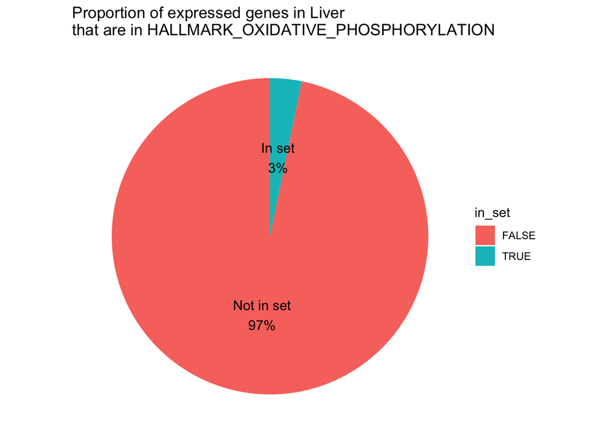

```r
# You pick the tissue
# You pick the gene set
mytissue <- "Liver"
mygeneset <- "HALLMARK_OXIDATIVE_PHOSPHORYLATION"

# Remember this dataset has multiple rows per gene (and per gene-tissue combination)
gtex_hallmark %>%
  # Pick the tissue
  filter(tissue == mytissue) %>%
  # Get only highly expressed genes
  filter(expressed_high == TRUE) %>%
  # Make an indicator for whether each gene is in your gene set
  mutate(in_set = gene_symbol %in% genes_in_set(mygeneset)) %>%
  # We don't want to double-count any genes!!
  dplyr::select(gene_symbol,in_set) %>%
  unique() %>%
  # Now we have have the right genes, so tabulate
  count(in_set) %>%
  # Convert to a proportion
  mutate(prop = n / sum(n),
         label = paste0(
           if_else(in_set,
                   "In set",
                   "Not in set"),
           "\n", scales::percent(prop))) %>%
  # Plot
  # Note the aesthetics carefully!
  ggplot(aes(x="", y = n, fill = in_set)) +
  # Use geom_col but convert bar --> circle by using polar coordinates
  geom_col() +
  coord_polar(theta="y") +
  # Show the percentages on the graph
  # (Make sure the text doesn't pile up)
  geom_text(aes(label = label),
            position = position_stack(vjust = 0.5),
            size = 4) +
  # Remove unwanted plot background
  theme_void() +
  # Title
  ggtitle(paste("Proportion of expressed genes in",
                mytissue,
                "\nthat are in",
                mygeneset))
```

Now try adapting the code above to make your own circle graph to answer the following question.

Of the genes in the `"HALLMARK_NOTCH_SIGNALING"` gene set, what tissues are they highly expressed in? (If a gene is highly expressed in multiple tissues, you can double-count it).

[figure not shown]

```r
gtex_hallmark %>%
  filter(gs_name == "HALLMARK_NOTCH_SIGNALING") %>%
  filter(expressed_high == TRUE) %>%
  count(tissue) %>%
    mutate(prop = n / sum(n),
         label = paste0(
           tissue,
           "\n", scales::percent(prop))) %>%
    ggplot(aes(x = "", y = n, fill = tissue)) +
  geom_col(width=1) +
  coord_polar(theta="y") +
  geom_text(aes(label = label),
            position = position_stack(vjust = 0),
            size = 1) +
  theme_void() +
  ggtitle("") +
  theme(legend.position = "none")
```

- I think thus chunk is garbage:

```r
tissue_selected <- "Liver"
gs <- "HALLMARK_OXIDATIVE_PHOSPHORYLATION"

set_genes <- genes_in_set(gs)

df <- gtex_hallmark %>%
  filter(tissue == tissue_selected & expressed_high == TRUE) %>%
  mutate(in_set = gene_symbol %in% set_genes) %>%
  count(in_set) %>%
  mutate(prop = n / sum(n),
         label = paste0(if_else(in_set, "In set", "Not in set"), "\n", scales::percent(prop)))

ggplot(df, aes(x = "", y = n, fill = in_set)) +
  geom_col(width = 1, color = "white") +
  coord_polar(theta = "y") +
  geom_text(aes(label = label), position = position_stack(vjust = 0.5), size = 4) +
  theme_void() +
  labs(title = paste("Proportion of expressed genes in", tissue, "\nthat are in", gs),
       fill = NULL)
```

### Stacked bars adding up to 100%

- Need to provide an example of this (though it’s covered in a previous exercise)
- This chunk is garbage:

```r
df <- map_dfr(sets_use, function(gs) {
  set_genes <- genes_in_set(gs)
  gtex_long %>%
    filter(tissue %in% tissues_use) %>%
    mutate(gs = gs,
           group = if_else(gene_symbol %in% set_genes, "In set", "Not in set")) %>%
    group_by(gs, tissue, group) %>%
    summarise(n_genes = n_distinct(gene_symbol), .groups = "drop") %>%
    group_by(gs, tissue) %>%
    mutate(prop = n_genes / sum(n_genes)) %>%
    ungroup()
})

ggplot(df, aes(x = tissue, y = prop, fill = group)) +
  geom_col() +
  facet_wrap(~gs, ncol = 2) +
  scale_y_continuous(labels = scales::percent) +
  theme_minimal() +
  theme(axis.text.x = element_text(angle = 35, hjust = 1)) +
  labs(title = "100% stacked bars: In-set vs Not-in-set across tissues",
       x = NULL, y = "Proportion of expressed genes", fill = NULL)
```

### Stacked density plots

- how to (both versions)
- include faceting

## Nested proportions

### Mosaic plot and treemap

Suppose we have two categorical variables and want to see how they’re related.

Below, `genes` is a data frame listing each Emsembl gene’s `biotype` and `chr_group` (X, Y, MT, or Autosome). Note there are a lot of biotypes, so in our plots we’ll only use the top few.

```r
mart <- useEnsembl(biomart = "genes", dataset = "hsapiens_gene_ensembl")

genes <- getBM(
  attributes = c("ensembl_gene_id", "gene_biotype", "chromosome_name"),
  mart = mart
) %>%
  filter(chromosome_name %in% c(as.character(1:22), "X", "Y", "MT")) %>%
  mutate(
    chr_group = case_when(
      chromosome_name == "X"  ~ "X",
      chromosome_name == "Y"  ~ "Y",
      chromosome_name == "MT" ~ "MT",
      TRUE ~ "Autosome"
    )
  )

# Get top biotypes
top_biotypes <- genes %>% count(gene_biotype, sort = TRUE) %>% slice_head(n = 6) %>% pull(gene_biotype)

# Filter down a bit
genes2 <- genes %>% mutate(gene_biotype = if_else(gene_biotype %in% top_biotypes, gene_biotype, "Other"))

# Tabular view of the data
kable(table(genes2$chr_group, genes2$gene_biotype))
```

|  | lncRNA | misc_RNA | Other | processed_pseudogene | protein_coding | snRNA | unprocessed_pseudogene |
| --- | --- | --- | --- | --- | --- | --- | --- |
| Autosome | 33853 | 2099 | 7750 | 8678 | 19156 | 1800 | 1688 |
| MT | 0 | 0 | 24 | 0 | 13 | 0 | 0 |
| X | 838 | 100 | 297 | 673 | 867 | 84 | 99 |
| Y | 189 | 8 | 99 | 136 | 61 | 17 | 162 |

We can make a treemap with `geom_treemap` from the `treemapify` package. The data first need to be processed into a summary table of counts in each biotype-chromosome pair.

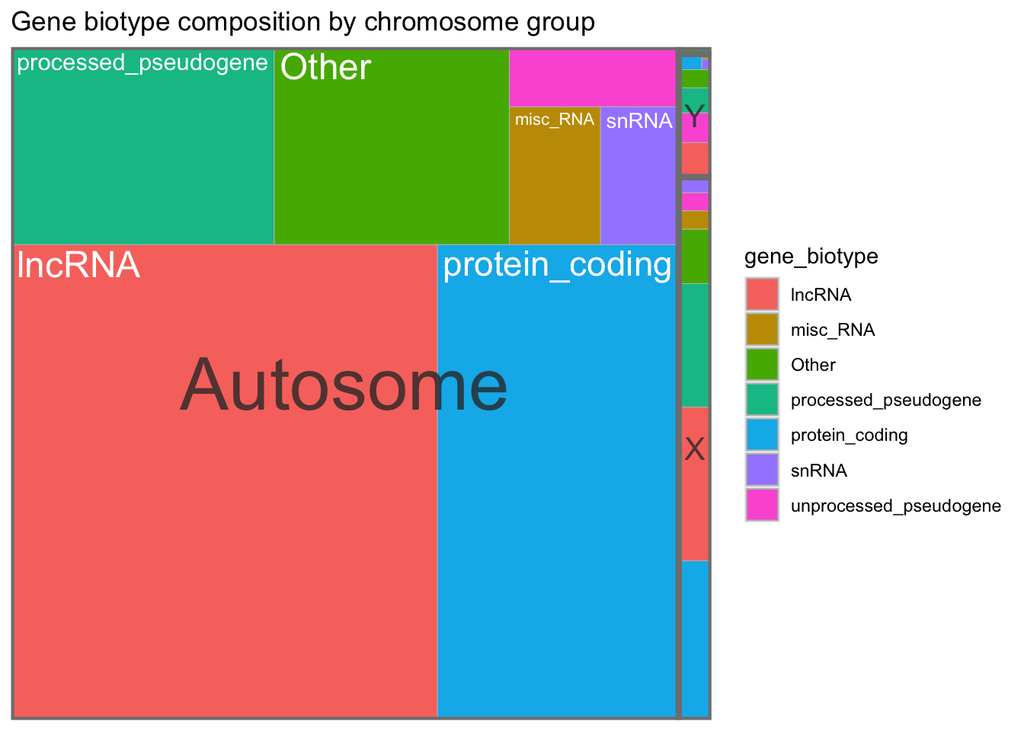

```r
genes2 %>%
  group_by(chr_group, gene_biotype) %>%
  summarize(n=n()) %>%
ggplot(.,
       aes(area = n,
           fill = gene_biotype,
           label = gene_biotype,
           subgroup = chr_group)) +
  geom_treemap() +
  geom_treemap_subgroup_border() +
  geom_treemap_subgroup_text(place = "center", alpha = 0.8) +
  geom_treemap_text(reflow = TRUE, colour = "white", min.size = 7) +
  ggtitle("Gene biotype composition by chromosome group")
```

Here’s a mosaic plot made with `geom_mosaic` from the `ggmosaic` package. We tabulates counts as exactly as above, but the aesthetics for this geom work a little differently. This plot could still be improved a bit.

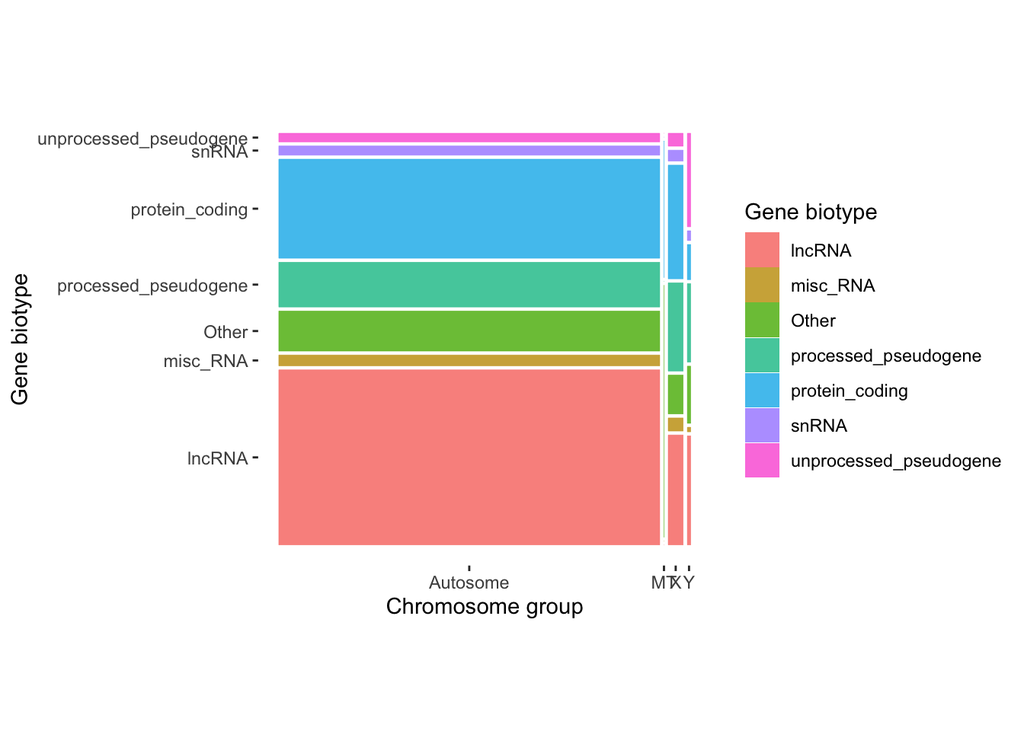

```r
genes2 %>%
  group_by(chr_group, gene_biotype) %>%
  summarize(n=n()) %>%
ggplot(.) +
  geom_mosaic(aes(x = product(chr_group),
                  fill = gene_biotype,
                  weight = n)) +
  theme_mosaic() +
  labs(x = "Chromosome group", y = "Gene biotype", fill = "Gene biotype")
```

### Concentric donut plot

I haven’t found a great way to make this type of plot. (I’m not sure they’re terribly useful, anyway.)

## Overlaps

Let’s pick several gene sets and use several plots to compare how they overlap.

```r
mygeneset1 <- genes_in_set("HALLMARK_UV_RESPONSE_DN")
mygeneset2 <- genes_in_set("HALLMARK_SPERMATOGENESIS")
mygeneset3 <- genes_in_set("HALLMARK_UV_RESPONSE_UP")
mygeneset4 <- genes_in_set("HALLMARK_REACTIVE_OXYGEN_SPECIES_PATHWAY")
mygeneset5 <- genes_in_set("HALLMARK_MITOTIC_SPINDLE")
```

Some of the plotting functions need more structure.

Let’s make a matrix (a data frame, really) with indicators for whether each gene is in each set.

```r
# First put the genes together in one big vector
my_genes <- unique(
  c(mygeneset1,
    mygeneset2,
    mygeneset3,
    mygeneset4))

# Make data frame of indicators
gene_upset_data_indicators <- data.frame(
  HALLMARK_UV_RESPONSE_DN=ifelse(my_genes %in% mygeneset1,1,0),
  HALLMARK_SPERMATOGENESIS=ifelse(my_genes %in% mygeneset2,1,0),
  HALLMARK_UV_RESPONSE_UP=ifelse(my_genes %in% mygeneset3,1,0),
  HALLMARK_REACTIVE_OXYGEN_SPECIES_PATHWAY=ifelse(my_genes %in% mygeneset4,1,0),
  HALLMARK_MITOTIC_SPINDLE=ifelse(my_genes %in% mygeneset5,1,0)
)
head(gene_upset_data_indicators)
```

```
##   HALLMARK_UV_RESPONSE_DN HALLMARK_SPERMATOGENESIS HALLMARK_UV_RESPONSE_UP
## 1                       1                        0                       0
## 2                       1                        0                       0
## 3                       1                        0                       0
## 4                       1                        0                       0
## 5                       1                        0                       0
## 6                       1                        0                       0
##   HALLMARK_REACTIVE_OXYGEN_SPECIES_PATHWAY HALLMARK_MITOTIC_SPINDLE
## 1                                        1                        0
## 2                                        0                        0
## 3                                        0                        0
## 4                                        0                        0
## 5                                        0                        0
## 6                                        0                        0
```

### Venn diagrams

Making Venn diagrams with the `VennDiagram` package is fairly straightforward. You simply bundle the vectors (sets) together in a list.

```r
venn.diagram(
  x = list(mygeneset1,
           mygeneset2,
           mygeneset3,
           mygeneset4,
           mygeneset5),
  category.names = paste("Set", 1:5),
  filename = '~/Desktop/venn_diagram_plain.png',
  output=TRUE
)
```

```
## [1] 1
```

Adding color can make the plot a little easier to interpret.

```r
# Chart fancier
myCol <- brewer.pal(5, "Spectral")

venn.diagram(
  x = list(mygeneset1,
           mygeneset2,
           mygeneset3,
           mygeneset4,
           mygeneset5),
  category.names = paste("Set", 1:5),
  filename = '~/Desktop/venn_diagram_fancier.png',
  output=TRUE,
  fill = myCol,
)
```

```
## [1] 1
```

### Heatmap for overlap

A heatmap overcomes some of the limitations of Venn diagrams.

A simple way to make the heatmap:

- `geom_tile`
- aesthetics `x`, `y`, and `fill`

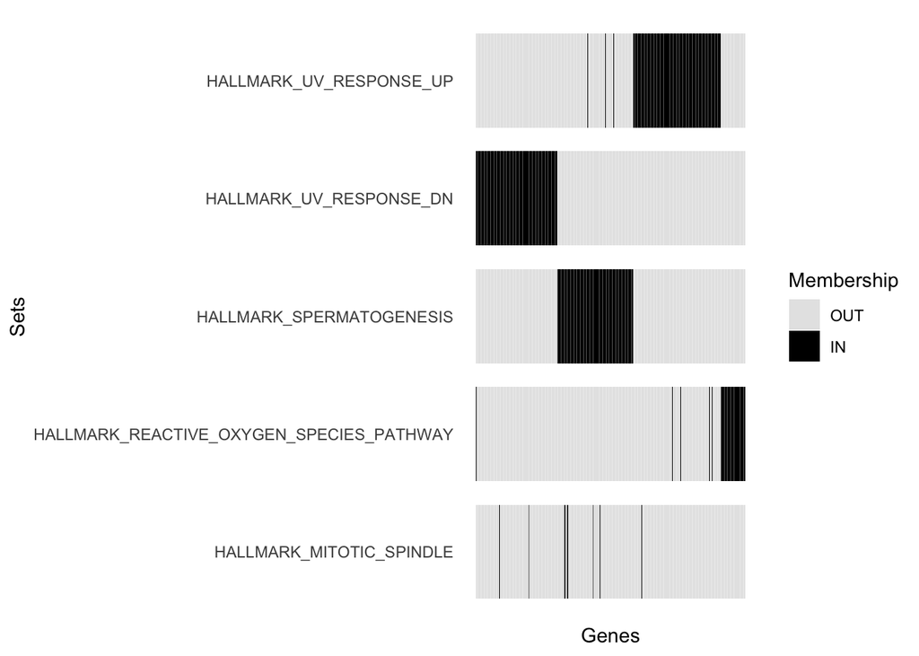

```r
# Add a gene identifier
gene_upset_data_indicators$gene <- 1:nrow(gene_upset_data_indicators)

# Need the data in long format
df <- pivot_longer(gene_upset_data_indicators,
                   -gene,
                   names_to = "set",
                   values_to = "in_set")

# Plot
# I put a small gap between each gene
# That way the genes don't form contiguous blocks and can be counted
ggplot(df, aes(x = gene, y = set, fill = factor(in_set))) +
  geom_tile(width = 0.8, height = 0.8) +
  scale_fill_manual(
    values = c("0" = "grey90", "1" = "black"),
    labels = c("OUT", "IN"),
    name = "Membership"
  ) +
  labs(x = "Genes", y = "Sets") +
  theme_minimal() +
  theme(
    axis.text.x = element_blank(),
    axis.ticks.x = element_blank(),
    panel.grid = element_blank()
  )
```

### Upset plot

To make an upset plot with the `UpSetR` package, we first need to process the data a bit more.

Right now we just have gene lists. We need a data frame indicating set membership.

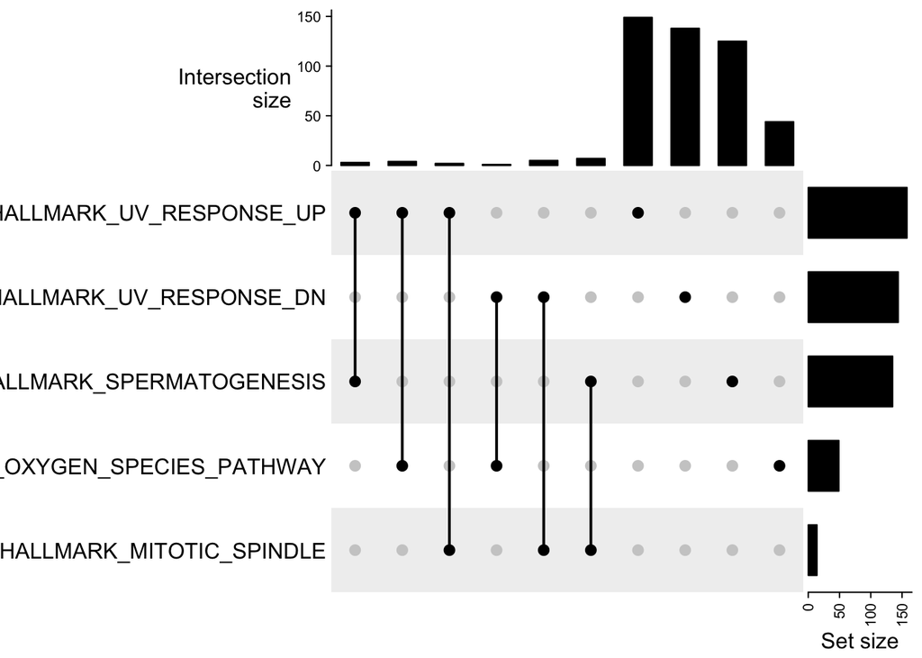

```r
# Create combination object
gene_comb <- make_comb_mat(gene_upset_data_indicators, top_n_sets = 6)

# Make plot
gene_comb <- gene_comb[comb_degree(gene_comb) > 0]
UpSet(gene_comb)
```

Observe that we can spruce up the plot, though the code is a little complicated:

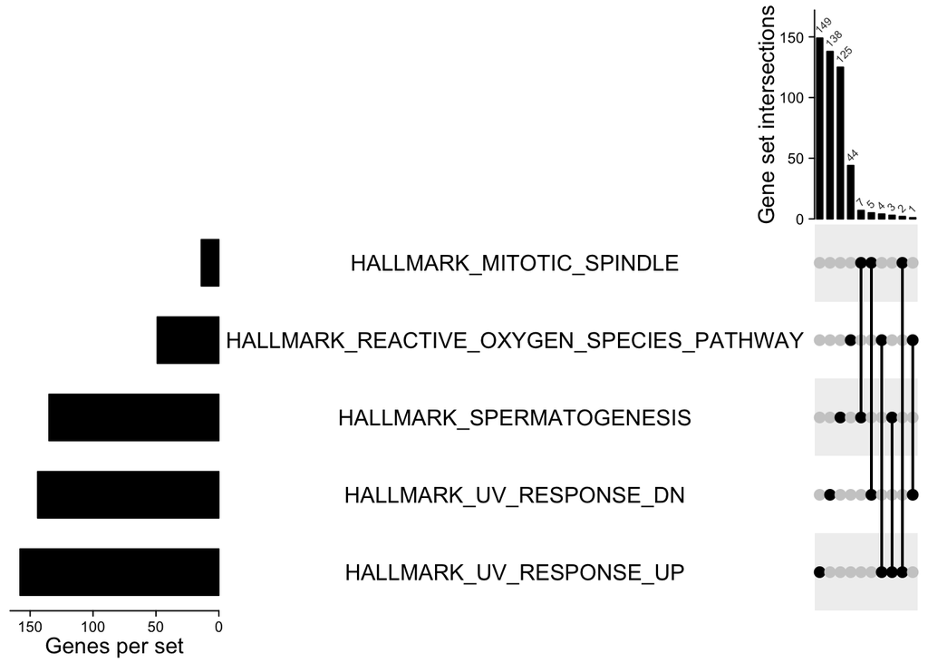

```r
ss <- set_size(gene_comb)
cs <- comb_size(gene_comb)
ht <- UpSet(gene_comb,
           set_order = order(ss),
           comb_order = order(comb_degree(gene_comb), -cs),
           top_annotation = HeatmapAnnotation(
             "Gene set intersections" = anno_barplot(
               cs,
               ylim = c(0, max(cs)*1.1),
               border = FALSE,
               gp = gpar(fill = "black"),
               height = unit(4, "cm")),
             annotation_name_side = "left",
             annotation_name_rot = 90),
           left_annotation = rowAnnotation(
             "Genes per set" = anno_barplot(-ss,
                                            baseline = 0,
                                            axis_param = list(
                                              at = c(0, -50, -100, -150,-200),
                                              labels = c(0, 50, 100, 150, 200),
                                              labels_rot = 0),
                                            border = FALSE,
                                            gp = gpar(fill = "black"),
                                            width = unit(4, "cm")),
             set_name = anno_text(set_name(gene_comb),
                                  location = 0.5,
                                  just = "center",
                                  width = max_text_width(set_name(gene_comb)) + unit(4, "mm"))
           ),
           right_annotation = NULL,
           show_row_names = FALSE)
ht = draw(ht)
od = column_order(ht)
decorate_annotation("Gene set intersections", {
  grid.text(cs[od], x = seq_along(cs), y = unit(cs[od], "native") + unit(2, "pt"),
            default.units = "native", just = c("left", "bottom"),
            gp = gpar(fontsize = 6, col = "#404040"), rot = 45)
})
```

Here’s another upset plot example that uses non-genetic data. This example comes from the creator(s) of the package.

`movies` contains 3,883 movies. The sets are the genres a movie can belong to. For example, `"Army of Darkness (1993) "` belongs to the genres/sets `"Action"`, `"Adventure"`, `"Comedy"`, `"Horror"`, and `"SciFi"`.

```r
# Another example - a movie dataset
# There are a lot of possibly genres - just just the top 6
movies <- read.csv(system.file("extdata", "movies.csv", package = "UpSetR"),
                  header = TRUE, sep = ";")
head(movies)
```

```
##                                 Name ReleaseDate Action Adventure Children
## 1                   Toy Story (1995)        1995      0         0        1
## 2                     Jumanji (1995)        1995      0         1        1
## 3            Grumpier Old Men (1995)        1995      0         0        0
## 4           Waiting to Exhale (1995)        1995      0         0        0
## 5 Father of the Bride Part II (1995)        1995      0         0        0
## 6                        Heat (1995)        1995      1         0        0
##   Comedy Crime Documentary Drama Fantasy Noir Horror Musical Mystery Romance
## 1      1     0           0     0       0    0      0       0       0       0
## 2      0     0           0     0       1    0      0       0       0       0
## 3      1     0           0     0       0    0      0       0       0       1
## 4      1     0           0     1       0    0      0       0       0       0
## 5      1     0           0     0       0    0      0       0       0       0
## 6      0     1           0     0       0    0      0       0       0       0
##   SciFi Thriller War Western AvgRating Watches
## 1     0        0   0       0      4.15    2077
## 2     0        0   0       0      3.20     701
## 3     0        0   0       0      3.02     478
## 4     0        0   0       0      2.73     170
## 5     0        0   0       0      3.01     296
## 6     0        1   0       0      3.88     940
```

```r
m <- make_comb_mat(movies, top_n_sets = 6)
m
```

```
## A combination matrix with 6 sets and 39 combinations.
##   ranges of combination set size: c(1, 1028).
##   mode for the combination size: distinct.
##   sets are on rows.
##
## Top 8 combination sets are:
##   Action Comedy Drama Horror Romance Thriller   code size
##                     x                         001000 1028
##               x                               010000  698
##                            x                  000100  216
##        x                                      100000  206
##                                             x 000001  183
##               x     x                         011000  180
##               x                    x          010010  160
##                     x              x          001010  158
##
## Sets are:
##          set size
##       Action  503
##       Comedy 1200
##        Drama 1603
##       Horror  343
##      Romance  471
##     Thriller  492
##   complement    2
```

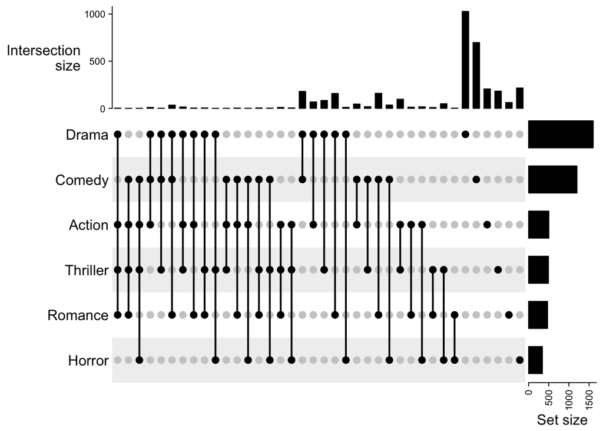

```r
m <- m[comb_degree(m) > 0]
UpSet(m)
```

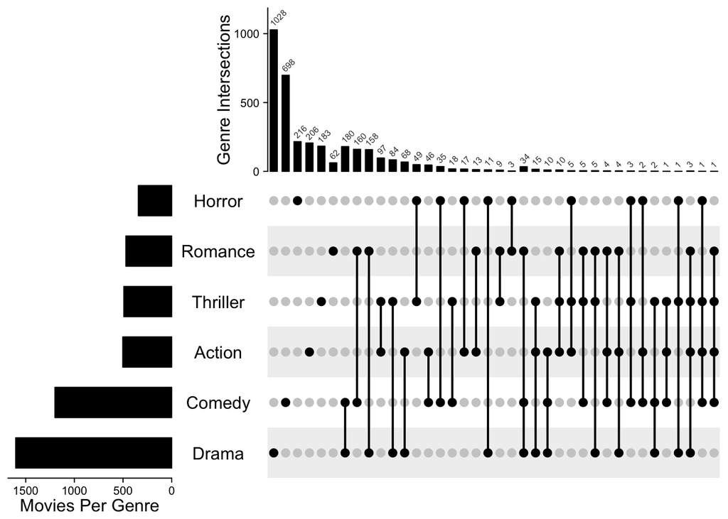

```r
# Customize the plot more
ss <- set_size(m)
cs <- comb_size(m)
ht <- UpSet(m,
           set_order = order(ss),
           comb_order = order(comb_degree(m), -cs),
           top_annotation = HeatmapAnnotation(
             "Genre Intersections" = anno_barplot(cs,
                                                  ylim = c(0, max(cs)*1.1),
                                                  border = FALSE,
                                                  gp = gpar(fill = "black"),
                                                  height = unit(4, "cm")
             ),
             annotation_name_side = "left",
             annotation_name_rot = 90),
           left_annotation = rowAnnotation(
             "Movies Per Genre" = anno_barplot(-ss,
                                               baseline = 0,
                                               axis_param = list(
                                                 at = c(0, -500, -1000, -1500),
                                                 labels = c(0, 500, 1000, 1500),
                                                 labels_rot = 0),
                                               border = FALSE,
                                               gp = gpar(fill = "black"),
                                               width = unit(4, "cm")
             ),
             set_name = anno_text(set_name(m),
                                  location = 0.5,
                                  just = "center",
                                  width = max_text_width(set_name(m)) + unit(4, "mm"))
           ),
           right_annotation = NULL,
           show_row_names = FALSE)
ht = draw(ht)
od = column_order(ht)
decorate_annotation("Genre Intersections", {
  grid.text(cs[od], x = seq_along(cs), y = unit(cs[od], "native") + unit(2, "pt"),
            default.units = "native", just = c("left", "bottom"),
            gp = gpar(fontsize = 6, col = "#404040"), rot = 45)
})
```

You can also make upset plots of genomic range data.

Check out https://jokergoo.github.io/ComplexHeatmap-reference/book/upset-plot.html#example-with-the-genomic-regions.

### Enrichment math

#### Question

Often we’d like to know if an overlap is “significant” in some sense.

Imagine you perform a differential expression (DE) analysis comparing cells treated with BPA vs control cells.

Each gene is tested for a difference in expression across the two conditions. After a significance threshold is applied, suppose you end up with a list of 8 genes.

You might inspect the list and notice 2 of the genes belong to a pathway you’re interested in (i.e., a gene set).

That is, your DE genes overlap with the gene set by 2. Is that likely to be due to chance?

What does this depend on?

- How many DE genes did you look at? `n=8`
- How big is the overlap? `k=2`
- How big was the gene set? `K=50`
- How big was the universe of genes? `N=?` (Pretend `N`=100, which is unrealistically tiny.)

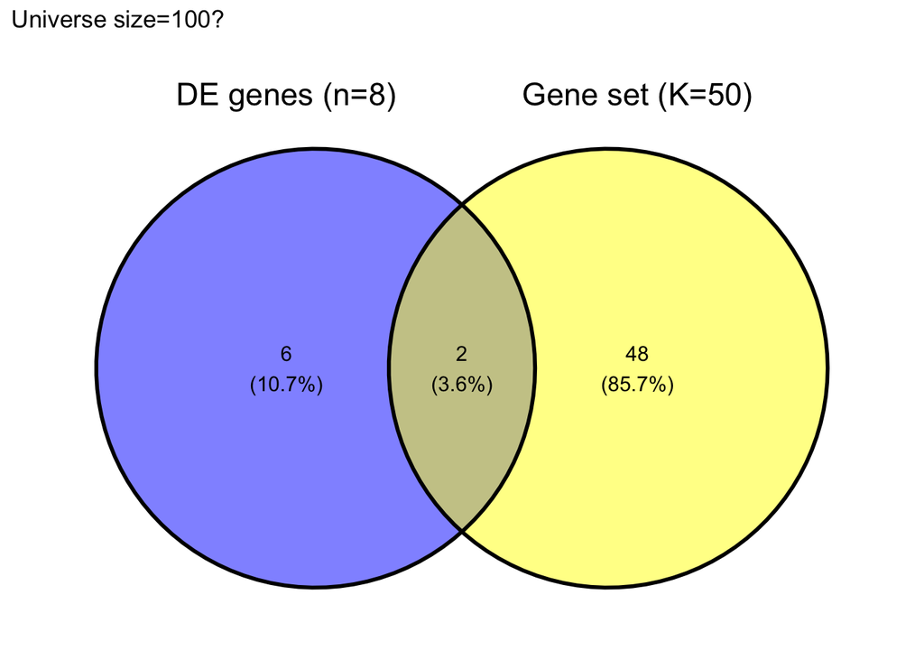

```r
#if (!require(devtools)) install.packages("devtools")
#devtools::install_github("yanlinlin82/ggvenn")
library(ggvenn)
degenes <- paste0("genes",1:8)
geneset <- paste0("genes",7:56)
ggvenn(list("DE genes (n=8)"=degenes, "Gene set (K=50)"=geneset)) + ggtitle("Universe size=100?")
```

If the DE genes were randomly drawn from the genome (the “universe”), how likely would it be to get `k=2` (or more) genes from the gene set?

- How many ways can you pick `n` genes out of `N` genes (without replacement)?
- How many ways can you pick, without replacement, `n` genes out of `N` and get `k` pathway genes, if there `K` pathway genes in total?

The number of distinct ways to choose `a` objects from `b` without replacement is

Try to apply this formula to work out a p-value by hand for the results above. You can use the `choose` function to help your calculations.

Then try using the `dypher` and/or `phyper` functions to check your work. These two functions evaluate probabilities for the hypergeometric distribution, which is the distribution that models our situation. (Read the argument descriptions for the functions.)

#### Answer

First, there are this many ways to pick `n=8` genes from a “universe” of size `N=100` genes:

$$\binom{N}{n} = \frac{N!}{n!(N-n)!} = \frac{100!}{8!(92)!}$$

How many ways are to pick out exactly `k=2` pathway genes in our “sample” of size `n=8`?

This is equivalent to picking `k=2` of the `K=50` pathway genes AND picking `n - k = 8 - 2 = 6` non-pathway genes out of the `N - K = 100 - 50 = 50` total non-pathway genes in the “universe”.

The number of ways to do that is:

$$\binom{K}{k} * \binom{N-K}{n-k} = \binom{50}{2} * \binom{50}{6} =
\frac{50!}{2!(48)!} * \frac{50!}{6!(44)!}$$
So the probability of getting an overlap of *exactly* `k=2` is then

$$\frac{\frac{50!}{2!(48)!} * \frac{50!}{6!(44)!} }{\frac{100!}{8!(92)!}}$$
We can calculate that in R.

```r
(factorial(50)/(factorial(2)*factorial(48))) * (factorial(50)/(factorial(6)*factorial(44))) / (factorial(100)/(factorial(8)*factorial(92)))
```

```
## [1] 0.1046071
```

We can verify this with `dhyper`, the probability density function for the hypergeometric distribution.

```r
# Note that the m, n, and k parameters have different meanings here
dhyper(x=2, m=50, n=50, k=8)
```

```
## [1] 0.1046071
```

Note we are not quite done. A p-value would be the probability of getting results *at least* this extreme, i.e., the probability that `k` is at least 2.

We can calculate like this:

```r
sum(dhyper(x=2:8, m=50, n=50, k=8))
```

```
## [1] 0.970277
```

In other words, getting at least `k=2` pathway genes among our `n=8` was not at all unlikely if `K=50` out of all `N=100` genes are pathway genes.

```r
sum(dhyper(x=2:8, m=50, n=19500, k=8))
```

```
## [1] 0.0001777401
```